# Risk Factor Analysis

## Outcome Variable

**Outcome Variable:** wast_rec90d

## Predictor Variables

**Intervention Variable:** hdlvry

**Adjustment Set:**

- arm
- sex
- W_mage
- meducyrs
- feducyrs
- hhwealth_quart
- single
- W_nrooms
- brthmon
- W_parity
- impsan
- delta_W_mage
- delta_meducyrs
- delta_feducyrs
- delta_hhwealth_quart
- delta_single
- delta_W_nrooms
- delta_brthmon
- delta_W_parity
- delta_impsan

## Stratifying Variables

The analysis was stratified on these variable(s):

- agecat
- studyid
- country

## Data Summary

| agecat | studyid | country | hdlvry | wast_rec90d | n_cell | n |
| --- | --- | --- | --- | --- | --- | --- |
| 0-24 months | CMC-V-BCS-2002 | INDIA | 0 | 0 | 115 | 320 |
| 0-24 months | CMC-V-BCS-2002 | INDIA | 0 | 1 | 199 | 320 |
| 0-24 months | CMC-V-BCS-2002 | INDIA | 1 | 0 | 4 | 320 |
| 0-24 months | CMC-V-BCS-2002 | INDIA | 1 | 1 | 2 | 320 |
| 0-24 months | COHORTS | INDIA | 0 | 0 | 784 | 1881 |
| 0-24 months | COHORTS | INDIA | 0 | 1 | 294 | 1881 |
| 0-24 months | COHORTS | INDIA | 1 | 0 | 643 | 1881 |
| 0-24 months | COHORTS | INDIA | 1 | 1 | 160 | 1881 |
| 0-24 months | EE | PAKISTAN | 0 | 0 | 106 | 322 |
| 0-24 months | EE | PAKISTAN | 0 | 1 | 107 | 322 |
| 0-24 months | EE | PAKISTAN | 1 | 0 | 53 | 322 |
| 0-24 months | EE | PAKISTAN | 1 | 1 | 56 | 322 |
| 0-24 months | GMS-Nepal | NEPAL | 0 | 0 | 65 | 590 |
| 0-24 months | GMS-Nepal | NEPAL | 0 | 1 | 68 | 590 |
| 0-24 months | GMS-Nepal | NEPAL | 1 | 0 | 205 | 590 |
| 0-24 months | GMS-Nepal | NEPAL | 1 | 1 | 252 | 590 |
| 0-24 months | IRC | INDIA | 0 | 0 | 159 | 395 |
| 0-24 months | IRC | INDIA | 0 | 1 | 227 | 395 |
| 0-24 months | IRC | INDIA | 1 | 0 | 3 | 395 |
| 0-24 months | IRC | INDIA | 1 | 1 | 6 | 395 |
| 0-24 months | JiVitA-3 | BANGLADESH | 0 | 0 | 5 | 129 |
| 0-24 months | JiVitA-3 | BANGLADESH | 0 | 1 | 7 | 129 |
| 0-24 months | JiVitA-3 | BANGLADESH | 1 | 0 | 67 | 129 |
| 0-24 months | JiVitA-3 | BANGLADESH | 1 | 1 | 50 | 129 |
| 0-24 months | JiVitA-4 | BANGLADESH | 0 | 0 | 302 | 1779 |
| 0-24 months | JiVitA-4 | BANGLADESH | 0 | 1 | 136 | 1779 |
| 0-24 months | JiVitA-4 | BANGLADESH | 1 | 0 | 984 | 1779 |
| 0-24 months | JiVitA-4 | BANGLADESH | 1 | 1 | 357 | 1779 |
| 0-24 months | NIH-Crypto | BANGLADESH | 0 | 0 | 79 | 310 |
| 0-24 months | NIH-Crypto | BANGLADESH | 0 | 1 | 139 | 310 |

[output cut: 114 more lines]

The following strata were considered:

- agecat: 0-24 months, studyid: CMC-V-BCS-2002, country: INDIA
- agecat: 0-24 months, studyid: COHORTS, country: INDIA
- agecat: 0-24 months, studyid: EE, country: PAKISTAN
- agecat: 0-24 months, studyid: GMS-Nepal, country: NEPAL
- agecat: 0-24 months, studyid: IRC, country: INDIA
- agecat: 0-24 months, studyid: JiVitA-3, country: BANGLADESH
- agecat: 0-24 months, studyid: JiVitA-4, country: BANGLADESH
- agecat: 0-24 months, studyid: NIH-Crypto, country: BANGLADESH
- agecat: 0-24 months, studyid: PROVIDE, country: BANGLADESH
- agecat: 0-24 months, studyid: SAS-CompFeed, country: INDIA
- agecat: 0-24 months, studyid: SAS-FoodSuppl, country: INDIA
- agecat: 0-24 months, studyid: TanzaniaChild2, country: TANZANIA, UNITED REPUBLIC OF
- agecat: 0-6 months, studyid: CMC-V-BCS-2002, country: INDIA
- agecat: 0-6 months, studyid: COHORTS, country: INDIA
- agecat: 0-6 months, studyid: EE, country: PAKISTAN
- agecat: 0-6 months, studyid: GMS-Nepal, country: NEPAL
- agecat: 0-6 months, studyid: IRC, country: INDIA
- agecat: 0-6 months, studyid: JiVitA-3, country: BANGLADESH
- agecat: 0-6 months, studyid: JiVitA-4, country: BANGLADESH
- agecat: 0-6 months, studyid: NIH-Crypto, country: BANGLADESH
- agecat: 0-6 months, studyid: PROVIDE, country: BANGLADESH
- agecat: 0-6 months, studyid: SAS-CompFeed, country: INDIA
- agecat: 0-6 months, studyid: SAS-FoodSuppl, country: INDIA
- agecat: 0-6 months, studyid: TanzaniaChild2, country: TANZANIA, UNITED REPUBLIC OF
- agecat: 6-24 months, studyid: CMC-V-BCS-2002, country: INDIA
- agecat: 6-24 months, studyid: COHORTS, country: INDIA
- agecat: 6-24 months, studyid: EE, country: PAKISTAN
- agecat: 6-24 months, studyid: GMS-Nepal, country: NEPAL
- agecat: 6-24 months, studyid: IRC, country: INDIA
- agecat: 6-24 months, studyid: JiVitA-3, country: BANGLADESH
- agecat: 6-24 months, studyid: JiVitA-4, country: BANGLADESH
- agecat: 6-24 months, studyid: NIH-Crypto, country: BANGLADESH
- agecat: 6-24 months, studyid: PROVIDE, country: BANGLADESH
- agecat: 6-24 months, studyid: SAS-CompFeed, country: INDIA
- agecat: 6-24 months, studyid: SAS-FoodSuppl, country: INDIA
- agecat: 6-24 months, studyid: TanzaniaChild2, country: TANZANIA, UNITED REPUBLIC OF

### Dropped Strata

Some strata were dropped due to rare outcomes:

- agecat: 0-24 months, studyid: CMC-V-BCS-2002, country: INDIA
- agecat: 0-24 months, studyid: IRC, country: INDIA
- agecat: 0-24 months, studyid: SAS-FoodSuppl, country: INDIA
- agecat: 0-24 months, studyid: TanzaniaChild2, country: TANZANIA, UNITED REPUBLIC OF
- agecat: 0-6 months, studyid: CMC-V-BCS-2002, country: INDIA
- agecat: 0-6 months, studyid: IRC, country: INDIA
- agecat: 0-6 months, studyid: JiVitA-3, country: BANGLADESH
- agecat: 0-6 months, studyid: SAS-FoodSuppl, country: INDIA
- agecat: 0-6 months, studyid: TanzaniaChild2, country: TANZANIA, UNITED REPUBLIC OF
- agecat: 6-24 months, studyid: CMC-V-BCS-2002, country: INDIA
- agecat: 6-24 months, studyid: COHORTS, country: INDIA
- agecat: 6-24 months, studyid: IRC, country: INDIA
- agecat: 6-24 months, studyid: JiVitA-3, country: BANGLADESH
- agecat: 6-24 months, studyid: NIH-Crypto, country: BANGLADESH
- agecat: 6-24 months, studyid: SAS-FoodSuppl, country: INDIA
- agecat: 6-24 months, studyid: TanzaniaChild2, country: TANZANIA, UNITED REPUBLIC OF

## Methods Detail

We’re interested in the causal parameters $E[Y_a]$ for all values of $a \in \mathcal{A}$. These parameters represent the mean outcome if, possibly contrary to fact, we intervened to set all units to have $A=a$. Under the randomization and positivity assumptions, these are identified by the statistical parameters $\psi_a=E_W[E_{Y|A,W}(Y|A=a,W)]$. In addition, we’re interested in the mean of $Y$, $E[Y]$ under no intervention (the observed mean). We will estimate these parameters by using SuperLearner to fit the relevant likelihood factors – $E_{Y|A,W}(Y|A=a,W)$ and $p(A=a|W)$, and then updating our likelihood fit using a joint TMLE.

For unadjusted analyses ($W=\{\}$), initial likelihoods were estimated using Lrnr_glm to estimate the simple $E(Y|A)$ and Lrnr_mean to estimate $p(A)$. For adjusted analyses, a small library containing Lrnr_glmnet, Lrnr_xgboost, and Lrnr_mean was used.

Having estimated these parameters, we will then use the delta method to estimate relative risks and attributable risks relative to a prespecified baseline level of $A$.

# Results Detail

## Results Plots

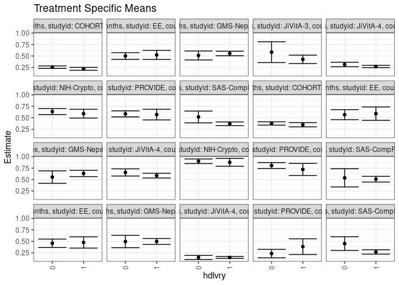

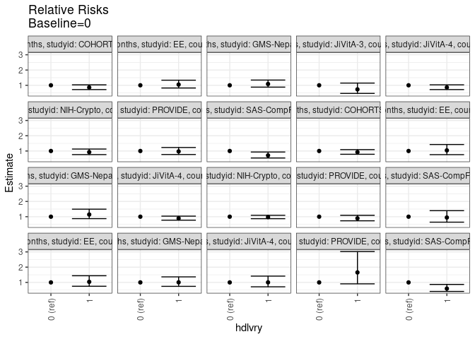

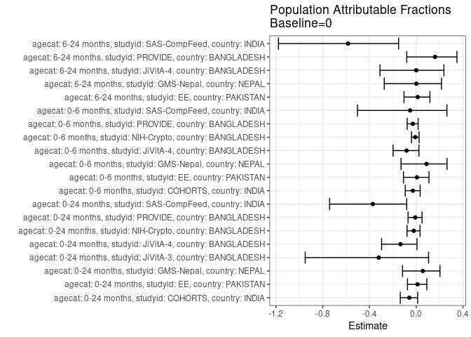

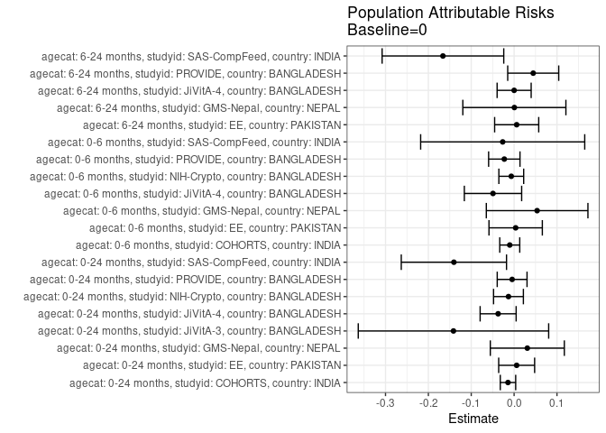

## Results Table

### Parameter: TSM

| agecat | studyid | country | intervention_level | baseline_level | estimate | ci_lower | ci_upper |
| --- | --- | --- | --- | --- | --- | --- | --- |
| 0-24 months | COHORTS | INDIA | 0 | NA | 0.2556245 | 0.2281186 | 0.2831304 |
| 0-24 months | COHORTS | INDIA | 1 | NA | 0.2197064 | 0.1879823 | 0.2514305 |
| 0-24 months | EE | PAKISTAN | 0 | NA | 0.5002488 | 0.4264560 | 0.5740417 |
| 0-24 months | EE | PAKISTAN | 1 | NA | 0.5237436 | 0.4240125 | 0.6234746 |
| 0-24 months | GMS-Nepal | NEPAL | 0 | NA | 0.5115263 | 0.4136329 | 0.6094198 |
| 0-24 months | GMS-Nepal | NEPAL | 1 | NA | 0.5554717 | 0.5059730 | 0.6049705 |
| 0-24 months | JiVitA-3 | BANGLADESH | 0 | NA | 0.5833333 | 0.3560459 | 0.8106207 |
| 0-24 months | JiVitA-3 | BANGLADESH | 1 | NA | 0.4273504 | 0.3351375 | 0.5195633 |
| 0-24 months | JiVitA-4 | BANGLADESH | 0 | NA | 0.3143699 | 0.2658330 | 0.3629069 |
| 0-24 months | JiVitA-4 | BANGLADESH | 1 | NA | 0.2705663 | 0.2457665 | 0.2953661 |
| 0-24 months | NIH-Crypto | BANGLADESH | 0 | NA | 0.6357144 | 0.5696321 | 0.7017966 |
| 0-24 months | NIH-Crypto | BANGLADESH | 1 | NA | 0.5895709 | 0.4931232 | 0.6860186 |
| 0-24 months | PROVIDE | BANGLADESH | 0 | NA | 0.5857829 | 0.5195573 | 0.6520085 |
| 0-24 months | PROVIDE | BANGLADESH | 1 | NA | 0.5697457 | 0.4532038 | 0.6862877 |
| 0-24 months | SAS-CompFeed | INDIA | 0 | NA | 0.5182449 | 0.3893909 | 0.6470988 |
| 0-24 months | SAS-CompFeed | INDIA | 1 | NA | 0.3685432 | 0.3284062 | 0.4086802 |
| 0-6 months | COHORTS | INDIA | 0 | NA | 0.3760006 | 0.3401208 | 0.4118803 |
| 0-6 months | COHORTS | INDIA | 1 | NA | 0.3479471 | 0.3016896 | 0.3942047 |
| 0-6 months | EE | PAKISTAN | 0 | NA | 0.5678051 | 0.4584581 | 0.6771522 |
| 0-6 months | EE | PAKISTAN | 1 | NA | 0.5906141 | 0.4449616 | 0.7362667 |
| 0-6 months | GMS-Nepal | NEPAL | 0 | NA | 0.5544535 | 0.4188170 | 0.6900899 |
| 0-6 months | GMS-Nepal | NEPAL | 1 | NA | 0.6334735 | 0.5638276 | 0.7031193 |
| 0-6 months | JiVitA-4 | BANGLADESH | 0 | NA | 0.6551775 | 0.5772132 | 0.7331417 |
| 0-6 months | JiVitA-4 | BANGLADESH | 1 | NA | 0.5860642 | 0.5342703 | 0.6378582 |
| 0-6 months | NIH-Crypto | BANGLADESH | 0 | NA | 0.9000000 | 0.8497073 | 0.9502927 |
| 0-6 months | NIH-Crypto | BANGLADESH | 1 | NA | 0.8771930 | 0.7908916 | 0.9634944 |
| 0-6 months | PROVIDE | BANGLADESH | 0 | NA | 0.8066436 | 0.7419086 | 0.8713786 |
| 0-6 months | PROVIDE | BANGLADESH | 1 | NA | 0.7205584 | 0.5888036 | 0.8523131 |
| 0-6 months | SAS-CompFeed | INDIA | 0 | NA | 0.5374159 | 0.3385389 | 0.7362929 |
| 0-6 months | SAS-CompFeed | INDIA | 1 | NA | 0.5082427 | 0.4458239 | 0.5706615 |
| 6-24 months | EE | PAKISTAN | 0 | NA | 0.4582801 | 0.3670332 | 0.5495269 |
| 6-24 months | EE | PAKISTAN | 1 | NA | 0.4755897 | 0.3524328 | 0.5987466 |
| 6-24 months | GMS-Nepal | NEPAL | 0 | NA | 0.4950392 | 0.3595054 | 0.6305729 |
| 6-24 months | GMS-Nepal | NEPAL | 1 | NA | 0.4981892 | 0.4337463 | 0.5626322 |
| 6-24 months | JiVitA-4 | BANGLADESH | 0 | NA | 0.1466995 | 0.1014989 | 0.1919000 |
| 6-24 months | JiVitA-4 | BANGLADESH | 1 | NA | 0.1471220 | 0.1252637 | 0.1689802 |
| 6-24 months | PROVIDE | BANGLADESH | 0 | NA | 0.2318310 | 0.1394291 | 0.3242328 |
| 6-24 months | PROVIDE | BANGLADESH | 1 | NA | 0.3836391 | 0.2123270 | 0.5549513 |
| 6-24 months | SAS-CompFeed | INDIA | 0 | NA | 0.4506748 | 0.3009433 | 0.6004063 |
| 6-24 months | SAS-CompFeed | INDIA | 1 | NA | 0.2682342 | 0.2204945 | 0.3159739 |

### Parameter: E(Y)

| agecat | studyid | country | intervention_level | baseline_level | estimate | ci_lower | ci_upper |
| --- | --- | --- | --- | --- | --- | --- | --- |
| 0-24 months | COHORTS | INDIA | NA | NA | 0.2413610 | 0.2219406 | 0.2607813 |
| 0-24 months | EE | PAKISTAN | NA | NA | 0.5062112 | 0.4470670 | 0.5653554 |
| 0-24 months | GMS-Nepal | NEPAL | NA | NA | 0.5423729 | 0.4984575 | 0.5862883 |
| 0-24 months | JiVitA-3 | BANGLADESH | NA | NA | 0.4418605 | 0.3551361 | 0.5285849 |
| 0-24 months | JiVitA-4 | BANGLADESH | NA | NA | 0.2771220 | 0.2556194 | 0.2986246 |
| 0-24 months | NIH-Crypto | BANGLADESH | NA | NA | 0.6225806 | 0.5684562 | 0.6767051 |
| 0-24 months | PROVIDE | BANGLADESH | NA | NA | 0.5811688 | 0.5245443 | 0.6377934 |
| 0-24 months | SAS-CompFeed | INDIA | NA | NA | 0.3777778 | 0.3394240 | 0.4161316 |
| 0-6 months | COHORTS | INDIA | NA | NA | 0.3658340 | 0.3390250 | 0.3926430 |
| 0-6 months | EE | PAKISTAN | NA | NA | 0.5714286 | 0.4842880 | 0.6585691 |
| 0-6 months | GMS-Nepal | NEPAL | NA | NA | 0.6081633 | 0.5464350 | 0.6698915 |
| 0-6 months | JiVitA-4 | BANGLADESH | NA | NA | 0.6059406 | 0.5632798 | 0.6486014 |
| 0-6 months | NIH-Crypto | BANGLADESH | NA | NA | 0.8934010 | 0.8497799 | 0.9370221 |
| 0-6 months | PROVIDE | BANGLADESH | NA | NA | 0.7837838 | 0.7252863 | 0.8422812 |
| 0-6 months | SAS-CompFeed | INDIA | NA | NA | 0.5107914 | 0.4514901 | 0.5700927 |
| 6-24 months | EE | PAKISTAN | NA | NA | 0.4642857 | 0.3910729 | 0.5374985 |
| 6-24 months | GMS-Nepal | NEPAL | NA | NA | 0.4956522 | 0.4389718 | 0.5523326 |
| 6-24 months | JiVitA-4 | BANGLADESH | NA | NA | 0.1467818 | 0.1275683 | 0.1659953 |
| 6-24 months | PROVIDE | BANGLADESH | NA | NA | 0.2764228 | 0.1950773 | 0.3577682 |
| 6-24 months | SAS-CompFeed | INDIA | NA | NA | 0.2846348 | 0.2390527 | 0.3302168 |

### Parameter: RR

| agecat | studyid | country | intervention_level | baseline_level | estimate | ci_lower | ci_upper |
| --- | --- | --- | --- | --- | --- | --- | --- |
| 0-24 months | COHORTS | INDIA | 0 | 0 | 1.0000000 | 1.0000000 | 1.0000000 |
| 0-24 months | COHORTS | INDIA | 1 | 0 | 0.8594890 | 0.7179066 | 1.0289938 |
| 0-24 months | EE | PAKISTAN | 0 | 0 | 1.0000000 | 1.0000000 | 1.0000000 |
| 0-24 months | EE | PAKISTAN | 1 | 0 | 1.0469660 | 0.8224171 | 1.3328247 |
| 0-24 months | GMS-Nepal | NEPAL | 0 | 0 | 1.0000000 | 1.0000000 | 1.0000000 |
| 0-24 months | GMS-Nepal | NEPAL | 1 | 0 | 1.0859104 | 0.8785075 | 1.3422781 |
| 0-24 months | JiVitA-3 | BANGLADESH | 0 | 0 | 1.0000000 | 1.0000000 | 1.0000000 |
| 0-24 months | JiVitA-3 | BANGLADESH | 1 | 0 | 0.7326007 | 0.4692527 | 1.1437415 |
| 0-24 months | JiVitA-4 | BANGLADESH | 0 | 0 | 1.0000000 | 1.0000000 | 1.0000000 |
| 0-24 months | JiVitA-4 | BANGLADESH | 1 | 0 | 0.8606622 | 0.7189757 | 1.0302704 |
| 0-24 months | NIH-Crypto | BANGLADESH | 0 | 0 | 1.0000000 | 1.0000000 | 1.0000000 |
| 0-24 months | NIH-Crypto | BANGLADESH | 1 | 0 | 0.9274148 | 0.7631141 | 1.1270898 |
| 0-24 months | PROVIDE | BANGLADESH | 0 | 0 | 1.0000000 | 1.0000000 | 1.0000000 |
| 0-24 months | PROVIDE | BANGLADESH | 1 | 0 | 0.9726227 | 0.7696515 | 1.2291211 |
| 0-24 months | SAS-CompFeed | INDIA | 0 | 0 | 1.0000000 | 1.0000000 | 1.0000000 |
| 0-24 months | SAS-CompFeed | INDIA | 1 | 0 | 0.7111372 | 0.5421918 | 0.9327254 |
| 0-6 months | COHORTS | INDIA | 0 | 0 | 1.0000000 | 1.0000000 | 1.0000000 |
| 0-6 months | COHORTS | INDIA | 1 | 0 | 0.9253899 | 0.7855699 | 1.0900959 |
| 0-6 months | EE | PAKISTAN | 0 | 0 | 1.0000000 | 1.0000000 | 1.0000000 |
| 0-6 months | EE | PAKISTAN | 1 | 0 | 1.0401705 | 0.7599569 | 1.4237053 |
| 0-6 months | GMS-Nepal | NEPAL | 0 | 0 | 1.0000000 | 1.0000000 | 1.0000000 |
| 0-6 months | GMS-Nepal | NEPAL | 1 | 0 | 1.1425187 | 0.8732549 | 1.4948087 |
| 0-6 months | JiVitA-4 | BANGLADESH | 0 | 0 | 1.0000000 | 1.0000000 | 1.0000000 |
| 0-6 months | JiVitA-4 | BANGLADESH | 1 | 0 | 0.8945122 | 0.7713336 | 1.0373618 |
| 0-6 months | NIH-Crypto | BANGLADESH | 0 | 0 | 1.0000000 | 1.0000000 | 1.0000000 |
| 0-6 months | NIH-Crypto | BANGLADESH | 1 | 0 | 0.9746589 | 0.8703902 | 1.0914184 |
| 0-6 months | PROVIDE | BANGLADESH | 0 | 0 | 1.0000000 | 1.0000000 | 1.0000000 |
| 0-6 months | PROVIDE | BANGLADESH | 1 | 0 | 0.8932798 | 0.7313924 | 1.0909995 |
| 0-6 months | SAS-CompFeed | INDIA | 0 | 0 | 1.0000000 | 1.0000000 | 1.0000000 |
| 0-6 months | SAS-CompFeed | INDIA | 1 | 0 | 0.9457158 | 0.6408237 | 1.3956698 |
| 6-24 months | EE | PAKISTAN | 0 | 0 | 1.0000000 | 1.0000000 | 1.0000000 |
| 6-24 months | EE | PAKISTAN | 1 | 0 | 1.0377708 | 0.7487654 | 1.4383253 |
| 6-24 months | GMS-Nepal | NEPAL | 0 | 0 | 1.0000000 | 1.0000000 | 1.0000000 |
| 6-24 months | GMS-Nepal | NEPAL | 1 | 0 | 1.0063632 | 0.7427933 | 1.3634574 |
| 6-24 months | JiVitA-4 | BANGLADESH | 0 | 0 | 1.0000000 | 1.0000000 | 1.0000000 |
| 6-24 months | JiVitA-4 | BANGLADESH | 1 | 0 | 1.0028798 | 0.7121355 | 1.4123267 |
| 6-24 months | PROVIDE | BANGLADESH | 0 | 0 | 1.0000000 | 1.0000000 | 1.0000000 |
| 6-24 months | PROVIDE | BANGLADESH | 1 | 0 | 1.6548225 | 0.9067675 | 3.0199997 |
| 6-24 months | SAS-CompFeed | INDIA | 0 | 0 | 1.0000000 | 1.0000000 | 1.0000000 |
| 6-24 months | SAS-CompFeed | INDIA | 1 | 0 | 0.5951835 | 0.4083884 | 0.8674179 |

### Parameter: PAR

| agecat | studyid | country | intervention_level | baseline_level | estimate | ci_lower | ci_upper |
| --- | --- | --- | --- | --- | --- | --- | --- |
| 0-24 months | COHORTS | INDIA | 0 | NA | -0.0142635 | -0.0322399 | 0.0037129 |
| 0-24 months | EE | PAKISTAN | 0 | NA | 0.0059623 | -0.0359384 | 0.0478631 |
| 0-24 months | GMS-Nepal | NEPAL | 0 | NA | 0.0308466 | -0.0554931 | 0.1171862 |
| 0-24 months | JiVitA-3 | BANGLADESH | 0 | NA | -0.1414729 | -0.3635901 | 0.0806444 |
| 0-24 months | JiVitA-4 | BANGLADESH | 0 | NA | -0.0372480 | -0.0792541 | 0.0047582 |
| 0-24 months | NIH-Crypto | BANGLADESH | 0 | NA | -0.0131337 | -0.0479151 | 0.0216477 |
| 0-24 months | PROVIDE | BANGLADESH | 0 | NA | -0.0046141 | -0.0393823 | 0.0301542 |
| 0-24 months | SAS-CompFeed | INDIA | 0 | NA | -0.1404671 | -0.2632360 | -0.0176982 |
| 0-6 months | COHORTS | INDIA | 0 | NA | -0.0101666 | -0.0334901 | 0.0131570 |
| 0-6 months | EE | PAKISTAN | 0 | NA | 0.0036235 | -0.0586135 | 0.0658604 |
| 0-6 months | GMS-Nepal | NEPAL | 0 | NA | 0.0537098 | -0.0648064 | 0.1722260 |
| 0-6 months | JiVitA-4 | BANGLADESH | 0 | NA | -0.0492369 | -0.1160968 | 0.0176231 |
| 0-6 months | NIH-Crypto | BANGLADESH | 0 | NA | -0.0065990 | -0.0355389 | 0.0223409 |
| 0-6 months | PROVIDE | BANGLADESH | 0 | NA | -0.0228598 | -0.0594508 | 0.0137313 |
| 0-6 months | SAS-CompFeed | INDIA | 0 | NA | -0.0266245 | -0.2180261 | 0.1647770 |
| 6-24 months | EE | PAKISTAN | 0 | NA | 0.0060056 | -0.0454188 | 0.0574301 |
| 6-24 months | GMS-Nepal | NEPAL | 0 | NA | 0.0006130 | -0.1196089 | 0.1208349 |
| 6-24 months | JiVitA-4 | BANGLADESH | 0 | NA | 0.0000823 | -0.0396290 | 0.0397936 |
| 6-24 months | PROVIDE | BANGLADESH | 0 | NA | 0.0445918 | -0.0149110 | 0.1040945 |
| 6-24 months | SAS-CompFeed | INDIA | 0 | NA | -0.1660400 | -0.3079320 | -0.0241480 |

### Parameter: PAF

| agecat | studyid | country | intervention_level | baseline_level | estimate | ci_lower | ci_upper |
| --- | --- | --- | --- | --- | --- | --- | --- |
| 0-24 months | COHORTS | INDIA | 0 | NA | -0.0590961 | -0.1360081 | 0.0126086 |
| 0-24 months | EE | PAKISTAN | 0 | NA | 0.0117784 | -0.0746306 | 0.0912394 |
| 0-24 months | GMS-Nepal | NEPAL | 0 | NA | 0.0568733 | -0.1167613 | 0.2035112 |
| 0-24 months | JiVitA-3 | BANGLADESH | 0 | NA | -0.3201754 | -0.9499839 | 0.1062166 |
| 0-24 months | JiVitA-4 | BANGLADESH | 0 | NA | -0.1344100 | -0.2961422 | 0.0071414 |
| 0-24 months | NIH-Crypto | BANGLADESH | 0 | NA | -0.0210956 | -0.0784333 | 0.0331936 |
| 0-24 months | PROVIDE | BANGLADESH | 0 | NA | -0.0079393 | -0.0695864 | 0.0501547 |
| 0-24 months | SAS-CompFeed | INDIA | 0 | NA | -0.3718246 | -0.7409896 | -0.0809386 |
| 0-6 months | COHORTS | INDIA | 0 | NA | -0.0277901 | -0.0935554 | 0.0340202 |
| 0-6 months | EE | PAKISTAN | 0 | NA | 0.0063410 | -0.1088204 | 0.1095419 |
| 0-6 months | GMS-Nepal | NEPAL | 0 | NA | 0.0883148 | -0.1296201 | 0.2642040 |
| 0-6 months | JiVitA-4 | BANGLADESH | 0 | NA | -0.0812569 | -0.1978231 | 0.0239656 |
| 0-6 months | NIH-Crypto | BANGLADESH | 0 | NA | -0.0073864 | -0.0403389 | 0.0245224 |
| 0-6 months | PROVIDE | BANGLADESH | 0 | NA | -0.0291659 | -0.0772814 | 0.0168005 |
| 0-6 months | SAS-CompFeed | INDIA | 0 | NA | -0.0521241 | -0.5025458 | 0.2632737 |
| 6-24 months | EE | PAKISTAN | 0 | NA | 0.0129352 | -0.1043969 | 0.1178018 |
| 6-24 months | GMS-Nepal | NEPAL | 0 | NA | 0.0012368 | -0.2733142 | 0.2165893 |
| 6-24 months | JiVitA-4 | BANGLADESH | 0 | NA | 0.0005607 | -0.3101503 | 0.2375845 |
| 6-24 months | PROVIDE | BANGLADESH | 0 | NA | 0.1613173 | -0.0805744 | 0.3490604 |
| 6-24 months | SAS-CompFeed | INDIA | 0 | NA | -0.5833441 | -1.1791332 | -0.1504476 |